**Nagarjuna Lokaraju**

**(Introduction to Analytics) - M2 Project Report**  
ALY6000 - 70483  
Northeastern University  
Dr. Dee Chiluiza  
Date: 30 October, 2021

```r
# Libraries
library(readxl)
library(readr)
library(tidyverse)
library(dplyr)
library(knitr)
library(kableExtra)
library(gmodels)
library(RColorBrewer)
library(scales)
# Data sets (add importing codes here)
M2Data <- read_xlsx("/Users/lokaraju/ALY6000 - Course 1/DataSets/M2data.xlsx")
```

INTRODUCTION

1. Importance of descriptive and inferential data

Both these methods form part of the statistics. Descriptive deals with presenting, organizing, and summarizing the data. It describes only a sample. Descriptive statistics helps us by describing the numbers which are generally required to understand the data.

Inferential statistics is all about getting to a conclusion about the whole data by observing a sample and assuming that all the factors and trends of such sample remains the same throughout. This is very important because it is hard to study huge data.

Example: Group of people collected a sample of water in Indian Ocean and studied it for salt content in the ocean water. Descriptive Statistics: They found that salt contents are 10 parts per thousand in that water. Inferential Statistics: It is impossible to study the whole sea water to get the salt content. Considering the results above and assuming it remains the same across the oceans and other water bodies is a clear example of Inferential Statistics.

2. Importance of proper data presentation.

We know data is the new oil and if such data is not processed for meaningful results, then it is waste. Hence Proper presentation of data will make it easy to understand, readable, simplified. It also makes the reader feel good going through it and meaningful insights. Example: Having a crude data from the company data base wouldn’t help you fetch the required results and run the analysis. Hence first we must curate the data by cleaning, removing the unwanted information, blanks etc. This will help the data get sorted and segregated and it can be ready for the usage. This curated data now can be processed for clear data, which in turn helps in presentation visually.

3. Practical Application of R in Data Analysis

R has various data types. R widely used in statistical/data computation. Everyday there are new packages getting added into R, which is making it more powerful for data analysis. We can create objects, operators, and various functions which are available in R will help the users to curate the data and present the visualizations. R is used in data analysis, risk analysis, statistical modeling, customer experience, targeted advertisement, financial reporting, drug testing, clinical trials. Example: Risk analysis is done using R by Lloyds organization. Amazon uses R to provide the product suggestions.

ANALYSIS

Task 1

**Presenting the first 3 and last 5 records from the dataset**

```r
knitr::opts_chunk$set(echo = TRUE)
first3 <- head(M2Data, 3)
last5 <- tail(M2Data,5)
t1 <- rbind(first3, last5)
knitr::kable(t1, caption = "<br>**Table 1 - first 3 and last 5 rows of the M2Data** ")%>%
  kableExtra::kable_styling(bootstrap_options = c("striped", "bordered", "hover", "condensed", "responsive", stripe_color = "blue"), full_width = FALSE, position = "left", html_font = "sans")%>%
  column_spec(6:10, bold = T, color = "teal", width = "2.5in")%>%
  column_spec(1, bold = T, color = "#515151", width = "2.5in")%>%
  column_spec(2:5, color = "#515151", width = "2.5in")%>%
  row_spec(0, color = "white", background = "#008080")
```

**Table 1 - first 3 and last 5 rows of the M2Data**

| Region | Market | Company_Segment | Product_Category | Product_SubCategory | Price | Quantity | Sales | Profits | ShippingCost |
| --- | --- | --- | --- | --- | --- | --- | --- | --- | --- |
| Central US | USCA | Consumer | Technology | Phones | 221.98 | 2 | 443.96 | 62.15 | 40.77 |
| Oceania | Asia Pacific | Corporate | Furniture | Chairs | 3709.40 | 9 | 33384.60 | -288.77 | 923.63 |
| Oceania | Asia Pacific | Consumer | Technology | Phones | 5175.17 | 9 | 46576.53 | 919.97 | 915.49 |
| Eastern Asia | Asia Pacific | Consumer | Furniture | Tables | 2614.69 | 7 | 18302.83 | -821.96 | 203.26 |
| Western US | USCA | Corporate | Office Supplies | Appliances | 69.48 | 1 | 69.48 | 20.84 | 12.04 |
| Oceania | Asia Pacific | Consumer | Technology | Copiers | 636.78 | 2 | 1273.56 | 286.50 | 203.20 |
| South America | LATAM | Corporate | Furniture | Bookcases | 2751.20 | 10 | 27512.00 | 110.00 | 203.13 |
| Southeastern Asia | Asia Pacific | Corporate | Technology | Phones | 1587.00 | 3 | 4761.00 | -76.56 | 203.08 |

Observations: The highest profit and sales are pertaining to Phones in Asia Pacific region.

Task 2

**Presenting a table with all categories of Market and their frequencies**

```r
CrossTable(M2Data$Market)
```

Cell Contents |————————-| | N | | N / Table Total | |————————-|

Total Observations in Table: 1000

```
         |       Africa | Asia Pacific |       Europe |        LATAM |         USCA |
         |--------------|--------------|--------------|--------------|--------------|
         |           54 |          365 |          248 |          133 |          200 |
         |        0.054 |        0.365 |        0.248 |        0.133 |        0.200 |
         |--------------|--------------|--------------|--------------|--------------|
```

```r
Markettabletable <- (M2Data$Market)
Table <- table(Markettabletable)
Table
```

Markettabletable Africa Asia Pacific Europe LATAM USCA 54 365 248 133 200

```r
Total = sum
Markettabletable = as.data.frame(addmargins(Table, FUN = Total))
colnames(Markettabletable) = c("Market", "Frequency")
Market_Table <- knitr::kable(Markettabletable, booktabs = TRUE, caption = "Table 6: Frequency Table of Market")%>%
  kableExtra::kable_styling(bootstrap_options = c("striped", "bordered", "hover", "condensed", "responsive", stripe_color = "blue"), full_width = FALSE, position = "left", html_font = "sans")%>%
  gsub("font-size: initial !important;", "font-size: 45pt !important;", .)%>%
  column_spec(2, bold = T, color = "teal", width = "1.5in")%>%
  column_spec(1, bold = T, color = "#515151", width = "1.5in")%>%
  row_spec(0, color = "white", background = "#008080")

Market_Table
```

Table 6: Frequency Table of Market

| Market | Frequency |
| --- | --- |
| Africa | 54 |
| Asia Pacific | 365 |
| Europe | 248 |
| LATAM | 133 |
| USCA | 200 |
| Total | 1000 |

Task 3

**Presenting the results of task 2 using a horizontal bar graph**

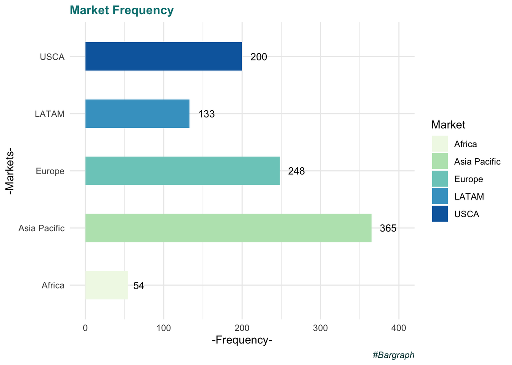

```r
Df1 <- data.frame(Market = c("Africa", "Asia Pacific", "Europe", "LATAM", "USCA"), Frequency = c(54, 365, 248, 133, 200))
barplot <- ggplot(data = Df1, aes(x = Market, y = Frequency, fill=Market))+geom_bar(stat = "identity", width=0.5)+scale_fill_brewer(palette="GnBu")+theme_minimal()+labs(title = "Market Frequency", caption = "#Bargraph", x="-Markets-", y="-Frequency-") +theme(plot.title = element_text(color = "#008080", size = 12, face = "bold"),plot.subtitle = element_text(color = "#282828"),plot.caption = element_text(color = "#004040", face = "italic"))+coord_flip()+geom_text(aes(label=Frequency), hjust=-0.5, size=3.5, position = position_dodge(0.9))+ylim(0, 400)
barplot
```

Observations: Number of people visiting the market is highest in Asia Pacific Region and lowest in Africa.

Task 4

**Observe Task 3 graph, Africa should be the Market with the lowest frequency**

```r
library(dplyr)
t4Africa = dplyr::filter(M2Data, Market=="Africa")

knitr::kable(t4Africa, caption = "<br>**African Market Data** ")%>%
  kableExtra::kable_styling(bootstrap_options = c("striped", "bordered", "hover", "condensed", "responsive", stripe_color = "blue"), full_width = FALSE, position = "left", html_font = "sans")%>%
  column_spec(6:10, bold = T, color = "teal", width = "2.5in")%>%
  column_spec(1, bold = T, color = "#515151", width = "2.5in")%>%
  column_spec(2:5, color = "#515151", width = "2.5in")%>%
  row_spec(0, color = "white", background = "#008080")
```

**African Market Data**

| Region | Market | Company_Segment | Product_Category | Product_SubCategory | Price | Quantity | Sales | Profits | ShippingCost |
| --- | --- | --- | --- | --- | --- | --- | --- | --- | --- |
| Western Africa | Africa | Consumer | Technology | Copiers | 2832.96 | 8 | 22663.68 | 311.52 | 903.04 |
| Eastern Africa | Africa | Consumer | Office Supplies | Appliances | 3409.74 | 6 | 20458.44 | 818.28 | 763.38 |
| Central Africa | Africa | Corporate | Technology | Phones | 3817.26 | 6 | 22903.56 | 1068.66 | 678.15 |
| Eastern Africa | Africa | Corporate | Technology | Phones | 2582.16 | 4 | 10328.64 | 593.88 | 627.17 |
| Central Africa | Africa | Consumer | Furniture | Chairs | 3808.80 | 8 | 30470.40 | 1523.52 | 588.13 |
| North Africa | Africa | Corporate | Technology | Copiers | 5301.24 | 14 | 74217.36 | 2597.28 | 568.45 |
| North Africa | Africa | Home Office | Office Supplies | Appliances | 2266.44 | 4 | 9065.76 | 113.28 | 556.45 |
| Central Africa | Africa | Consumer | Technology | Phones | 3856.14 | 6 | 23136.84 | 1465.20 | 533.99 |
| Eastern Africa | Africa | Consumer | Technology | Phones | 3834.00 | 6 | 23004.00 | 268.38 | 481.04 |
| Southern Africa | Africa | Home Office | Office Supplies | Storage | 2784.60 | 14 | 38984.40 | 779.52 | 422.25 |
| Southern Africa | Africa | Home Office | Office Supplies | Appliances | 1237.56 | 4 | 4950.24 | 606.36 | 400.03 |
| North Africa | Africa | Consumer | Technology | Phones | 1274.70 | 2 | 2549.40 | 140.16 | 399.96 |
| North Africa | Africa | Home Office | Furniture | Bookcases | 2615.94 | 6 | 15695.64 | 1072.44 | 384.41 |
| Southern Africa | Africa | Corporate | Technology | Phones | 2544.60 | 4 | 10178.40 | 814.20 | 383.01 |
| Southern Africa | Africa | Corporate | Technology | Copiers | 3799.08 | 12 | 45588.96 | 455.76 | 369.73 |
| Western Africa | Africa | Corporate | Technology | Phones | 3908.88 | 6 | 23453.28 | 1563.48 | 363.16 |
| Central Africa | Africa | Consumer | Office Supplies | Appliances | 1840.68 | 6 | 11044.08 | 496.98 | 359.58 |
| Southern Africa | Africa | Consumer | Technology | Phones | 2550.00 | 4 | 10200.00 | 714.00 | 355.92 |
| Central Africa | Africa | Consumer | Furniture | Bookcases | 2478.60 | 6 | 14871.60 | 49.50 | 349.87 |
| Central Africa | Africa | Consumer | Technology | Phones | 2549.76 | 4 | 10199.04 | 1172.88 | 336.65 |
| Western Africa | Africa | Consumer | Office Supplies | Appliances | 1239.00 | 4 | 4956.00 | 0.00 | 327.94 |
| Eastern Africa | Africa | Corporate | Office Supplies | Storage | 856.80 | 14 | 11995.20 | 265.44 | 321.23 |
| Central Africa | Africa | Consumer | Technology | Accessories | 976.08 | 4 | 3904.32 | 292.80 | 316.66 |
| Eastern Africa | Africa | Home Office | Furniture | Tables | 2134.44 | 4 | 8537.76 | 682.92 | 315.57 |
| Southern Africa | Africa | Corporate | Technology | Machines | 1867.50 | 6 | 11205.00 | 242.64 | 314.81 |
| Central Africa | Africa | Consumer | Technology | Phones | 3908.88 | 6 | 23453.28 | 1563.48 | 313.31 |
| Western Africa | Africa | Consumer | Technology | Copiers | 1429.44 | 4 | 5717.76 | 471.60 | 304.50 |
| Southern Africa | Africa | Corporate | Furniture | Tables | 1057.80 | 2 | 2115.60 | 158.64 | 304.36 |
| Central Africa | Africa | Home Office | Office Supplies | Storage | 1288.80 | 10 | 12888.00 | 90.00 | 296.08 |
| Southern Africa | Africa | Consumer | Technology | Accessories | 1464.12 | 6 | 8784.72 | 439.20 | 293.07 |
| Eastern Africa | Africa | Home Office | Technology | Machines | 1519.92 | 6 | 9119.52 | 653.40 | 286.20 |
| North Africa | Africa | Corporate | Office Supplies | Appliances | 1234.56 | 4 | 4938.24 | 246.84 | 284.70 |
| North Africa | Africa | Consumer | Technology | Phones | 2544.60 | 4 | 10178.40 | 1246.80 | 279.11 |
| Southern Africa | Africa | Corporate | Furniture | Bookcases | 889.02 | 6 | 5334.12 | 320.04 | 267.64 |
| North Africa | Africa | Corporate | Technology | Phones | 1457.28 | 8 | 11658.24 | 568.32 | 262.66 |
| Central Africa | Africa | Consumer | Technology | Machines | 1018.32 | 4 | 4073.28 | 183.24 | 255.69 |
| North Africa | Africa | Consumer | Furniture | Tables | 2880.18 | 6 | 17281.08 | 115.20 | 250.06 |
| Eastern Africa | Africa | Corporate | Office Supplies | Appliances | 553.44 | 8 | 4427.52 | 16.56 | 246.05 |
| North Africa | Africa | Corporate | Technology | Accessories | 1553.76 | 6 | 9322.56 | 730.26 | 245.57 |
| Central Africa | Africa | Consumer | Furniture | Bookcases | 1660.80 | 4 | 6643.20 | 83.04 | 244.07 |
| Central Africa | Africa | Consumer | Furniture | Tables | 3877.68 | 8 | 31021.44 | 930.48 | 242.90 |
| North Africa | Africa | Consumer | Technology | Machines | 613.26 | 2 | 1226.52 | 202.32 | 241.33 |
| North Africa | Africa | Consumer | Office Supplies | Appliances | 2243.88 | 4 | 8975.52 | 246.72 | 238.95 |
| Southern Africa | Africa | Consumer | Technology | Machines | 1885.32 | 6 | 11311.92 | 18.72 | 238.23 |
| Eastern Africa | Africa | Consumer | Furniture | Chairs | 1854.72 | 4 | 7418.88 | 778.92 | 236.26 |
| Western Africa | Africa | Home Office | Furniture | Chairs | 1669.25 | 12 | 20031.00 | -1558.15 | 234.85 |
| Western Africa | Africa | Home Office | Technology | Machines | 1253.76 | 4 | 5015.04 | 200.52 | 234.11 |
| Southern Africa | Africa | Corporate | Furniture | Bookcases | 2182.68 | 6 | 13096.08 | 327.24 | 232.24 |
| Central Africa | Africa | Corporate | Furniture | Bookcases | 1752.60 | 4 | 7010.40 | 455.64 | 228.70 |
| Western Africa | Africa | Consumer | Technology | Copiers | 1767.60 | 12 | 21211.20 | 0.00 | 226.68 |
| Central Africa | Africa | Consumer | Technology | Accessories | 976.08 | 4 | 3904.32 | 292.80 | 217.62 |
| Western Africa | Africa | Consumer | Technology | Phones | 1377.90 | 10 | 13779.00 | 289.20 | 214.97 |
| North Africa | Africa | Home Office | Technology | Copiers | 2280.60 | 6 | 13683.60 | 136.80 | 210.65 |
| Eastern Africa | Africa | Consumer | Technology | Copiers | 642.72 | 2 | 1285.44 | 224.94 | 205.74 |

```r
par(mfcol=c(1,2), mar=c(0, 0.7, 0, 0.7))

pietable <- table(t4Africa$Product_Category)
pietable
```

```
  Furniture Office Supplies      Technology
         13              11              30
```

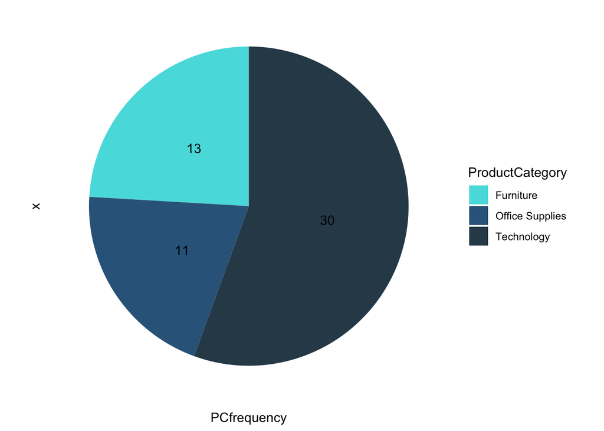

```r
df2 <- data.frame(ProductCategory = c("Furniture", "Office Supplies", "Technology"), PCfrequency = c(13, 11, 30))
pie <- ggplot(df2, aes(x="", y=PCfrequency, fill=ProductCategory)) + geom_bar(stat="identity", width=1)
pie+coord_polar("y", start=0)+geom_text(aes(label = PCfrequency), position = position_stack(vjust = 0.5))+scale_fill_manual(values=c("#55DDE0", "#33658A", "#2F4858"))+theme_classic() + theme(axis.line = element_blank(),axis.text = element_blank(),axis.ticks = element_blank(),plot.title = element_text(hjust = 0.5, color = "#FFFFFF"))
```

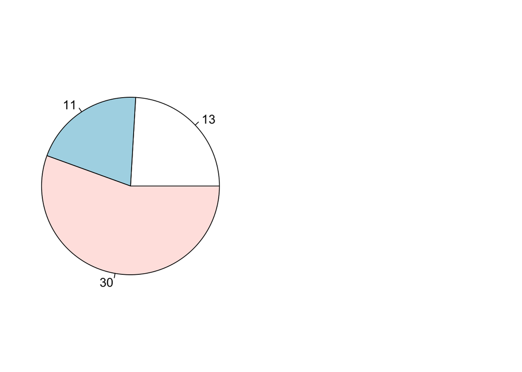

```r
Pie1 <- pie(pietable, labels = pietable, radius = 0.8)
```

Observations: Consumer behavior is more inclined towards the purchase of Gadgets or technology related material which is highest in Africa, accounting to frequency share of 55%. Non favorable atmosphere for office supplies.

Task 5

**Observe Task 4 graph, Africa should be the Market with the lowest frequency**

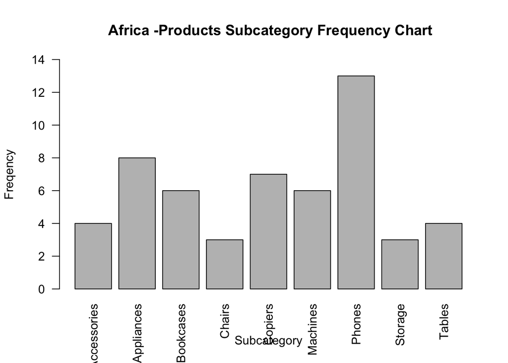

```r
library(RColorBrewer)
coul <- brewer.pal(9, "Oranges")
t5bar = barplot(table(t4Africa$Product_SubCategory), ylim = c(0, 14), las = 1, main=" Africa -Products Subcategory Frequency Chart",ylab="Freqency",xlab="Subcategory",las=2, cex.axis=1)
```

Task 6

**What are the mean sales per subcategory in the African Market?**

```r
#created an object MeanSales to store the data
MeanSales <- tapply(t4Africa$Sales, t4Africa$Product_SubCategory, mean)
MeanSales
```

Accessories Appliances Bookcases Chairs Copiers Machines 6478.980 8601.975 10441.840 19306.760 26338.286 6991.880 Phones Storage Tables 15001.698 21289.200 14738.970

```r
knitr::kable(MeanSales, caption = "<br>** Africa Product Sub Category MeanSales**", color = "black")%>%
  kableExtra::kable_styling(bootstrap_options = c("striped", "bordered", "hover", "condensed", "responsive", stripe_color = "blue"), full_width = FALSE, position = "left", html_font = "sans")%>%
  gsub("font-size: initial !important;", "font-size: 45pt !important;", .)%>%
  column_spec(2, bold = T, color = "teal", width = "1.5in")%>%
  column_spec(1, bold = T, color = "#515151", width = "1.5in")%>%
  row_spec(0, color = "white", background = "#008080")
```

** Africa Product Sub Category MeanSales**

|  | x |
| --- | --- |
| Accessories | 6478.980 |
| Appliances | 8601.975 |
| Bookcases | 10441.840 |
| Chairs | 19306.760 |
| Copiers | 26338.286 |
| Machines | 6991.880 |
| Phones | 15001.698 |
| Storage | 21289.200 |
| Tables | 14738.970 |

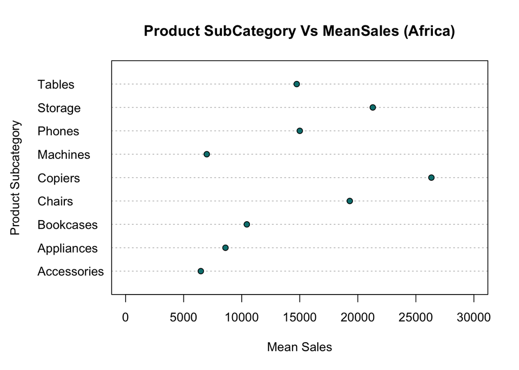

```r
#Present the data using a dotplot
dotchart(MeanSales,pch = 21, bg = "#008080", xlab = "Mean Sales", ylab = "Product Subcategory", main = "Product SubCategory Vs MeanSales (Africa)", xlim = c(0,30000))
```

Observations: Copiers subcategory under the technology category has the highest average sales in the African region, while the lowest being accessories. From the presentation of data in two formats, dot chart data is easily understandable to draw conclusions as to which has the highest and lowest sales in just a glace, but if we require the exact number it is preferable to use table.

Task 7

**What are the total sales per Region in the African Market?**

```r
RegionalSales <- tapply(t4Africa$Sales, t4Africa$Region, sum)
RegionalSales
```

Central Africa Eastern Africa North Africa Southern Africa Western Africa 205523.8 96575.4 178792.3 161749.4 116827.0

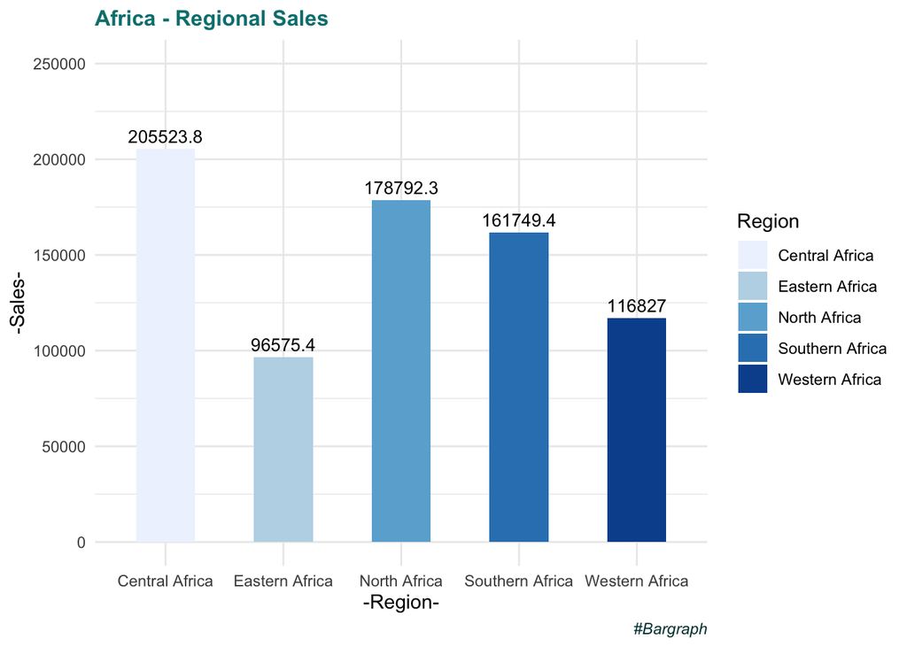

```r
df3 <- data.frame(Region = c("Central Africa", "Eastern Africa", "North Africa", "Southern Africa", "Western Africa"), RegionalSales = c(205523.8,96575.4,178792.3, 161749.4,116827.0))

regionalsalesplot <- ggplot(data = df3, aes(x = Region, y = RegionalSales, fill=Region))+geom_bar(stat = "identity", width=0.5)+scale_fill_brewer(palette="Blues")+theme_minimal()+labs(title = "Africa - Regional Sales ", caption = "#Bargraph", x="-Region-", y="-Sales-") +theme(plot.title = element_text(color = "#008080", size = 12, face = "bold"),plot.subtitle = element_text(color = "#282828"),plot.caption = element_text(color = "#004040", face = "italic"))+geom_text(aes(label=RegionalSales), vjust=-0.5, size=3.5, position = position_dodge(0.9))+ylim(0, 250000)

regionalsalesplot
```

Observations: Across the regions in Africa, the sum of sales have been highest in Central Africa with 27% share and the lowest being Eastern Africa with 12% share. Central Africa is the place where the markets should not lose a hold on and also try improving the sales in Eastern Africa by increasing the frequency of marketing.

Task 8

**What are the mean shipping costs per Region in the African Market?**

```r
MeanShippingCost <- tapply(t4Africa$ShippingCost, t4Africa$Region, mean)
MeanShippingCost
```

Central Africa Eastern Africa North Africa Southern Africa Western Africa 354.3857 386.9600 326.8583 325.5718 351.1562

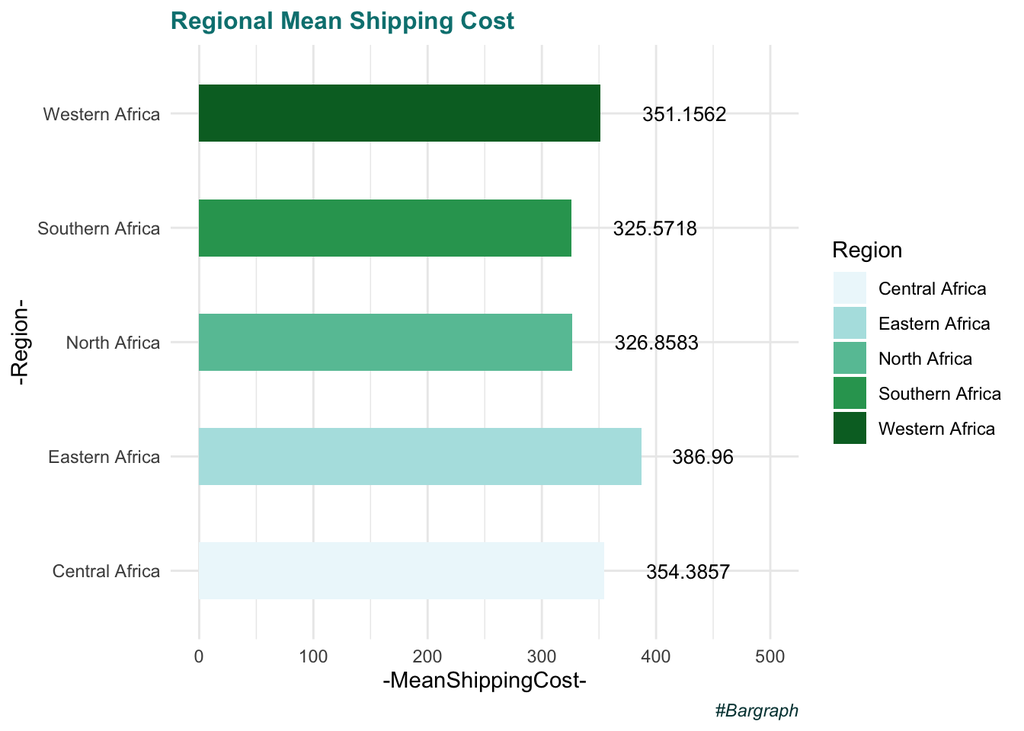

```r
df4 <- data.frame(Region = c("Central Africa", "Eastern Africa", "North Africa", "Southern Africa", "Western Africa"), MeanShippingCost = c(354.3857,386.9600,326.8583,325.5718,351.1562))

Shippingcostplot <- ggplot(data = df4, aes(x = Region, y = MeanShippingCost, fill=Region))+geom_bar(stat = "identity", width=0.5)+scale_fill_brewer(palette="BuGn")+theme_minimal()+labs(title = "Regional Mean Shipping Cost", caption = "#Bargraph", x="-Region-", y="-MeanShippingCost-")+theme(plot.title = element_text(color = "#008080", size = 12, face = "bold"),plot.subtitle = element_text(color = "#282828"),plot.caption = element_text(color = "#004040", face = "italic"))+geom_text(aes(label=MeanShippingCost), hjust=-0.5, size=3.5, position = position_dodge(0.9))+ylim(0, 500)+coord_flip()

Shippingcostplot
```

Task 9

Make a summary of tasks 3 to 8 What is the data analysis process you just followed and what information you were able to obtain?

Data analysis Process

1. Started with the data pertaining to all the regions, filtered in specific to frequency and found Africa with the least value.
2. Considering the value of Africa further started deduced the data and just accumulated Africa market data
3. Filtered to the African Product Category data. We can observe that consumers in Africa are more into purchase of gadgets because the frequency share of technology is 55%
4. Further deduced the data to check what is the major subcategory contributing and found that phones have the highest frequency which belongs to technology sector.
5. To understand the economics of the Product Subcategory, data of mean sales is derived. Here we observe that the copiers are having the highest mean sales value and lowest being the accessories. Hence, we can say that the more the frequency doesn’t mean the more are the sales.
6. Within Africa which region is the major contributor of sales : it is Central Africa accounting to 27% of the African sales with 12% being the lowest for Eastern Africa.
7. Mean Shipping cost is highest at the Eastern Africa, which might the possible reason of a smaller number of sales happening. Southern Africa having the least shipping cost is accounts for third highest regional sale.

Task 10

```r
#Explain the differences on data type designations used in R: integer, factor, double, numeric. Perform a search on the Internet to find this information.
#Remember to mention the author and year of your references.
```

Integer - Integers are part of numerical data without decimals. this form of data will never contain decimals. It is a discrete variable. If there aren’t any decimals in your data, R will automatically consider those as integers. Its command is as.integer()

Factor - Factor data type is nothing but characters but of special kind, just that it has a limited character count. We can know different levels of factor by sing the function levels(). If we need, we can convert the character string into the factor.

Numeric - very frequently used datatype in R is Numeric. It is for storing the numeric data be it either the decimal version or non-decimal. We can check the class of it by class() function. also you can check with Str() to know the structure.

Double - Number data with double precision is is double in R. R represents most of the numbers in double precision which is called as double in R. R coverts single to double data type while executing or computing.

Author - Antoine Soetewey 2019-12-30

Becker, R. A., Chambers, J. M. and Wilks, A. R. (1988) The New S Language. Wadsworth & Brooks/Cole.

Task 11

**Prepare the following R chunk in your report and present the two figures.**

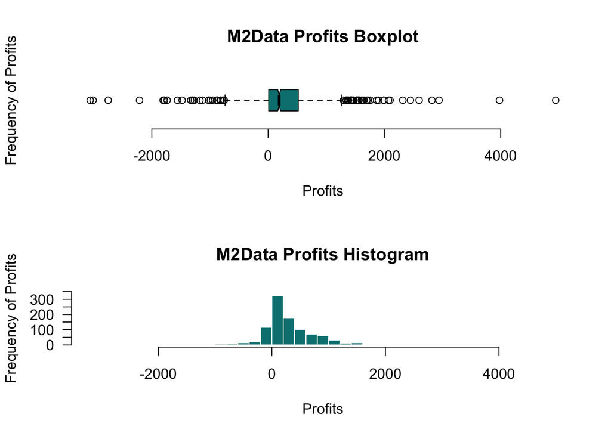

```r
#Prepare the following R chunk in your report and present the two figures.
#Add colors to both graphs, change orientation of y-axis labels in the histogram, improve x-axis label on the histogram.

#use par() code to organise graph in a matrix of 2 rows and 1 column.

par(mfcol = c(2,1))

#Presnt a boxplot of all profits
boxplot(M2Data$Profits, horizontal=T, col = "#008080", frame = FALSE, notch = TRUE, main = "M2Data Profits Boxplot",
        xlab = "Profits", ylab = "Frequency of Profits")

#presnt a histogram of all profits
hist(M2Data$Profits, breaks = 50, main = "M2Data Profits Histogram", xlab="Profits", ylab = "Frequency of Profits", border="white", col="#008080",las=1, ylim = c(0,350))
```

Task 12

Task 13

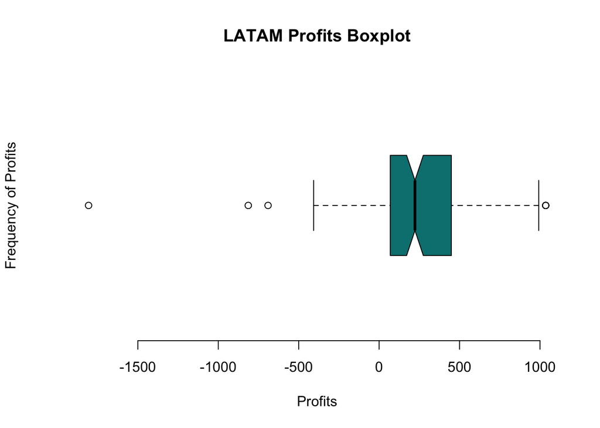

```r
#a

t13LATAM = dplyr::filter(M2Data, Market=="LATAM")


#b
boxplot(t13LATAM$Profits, horizontal=T, col = "#008080", frame = FALSE, notch = TRUE, main = "LATAM Profits Boxplot",
        xlab = "Profits", ylab = "Frequency of Profits")
```

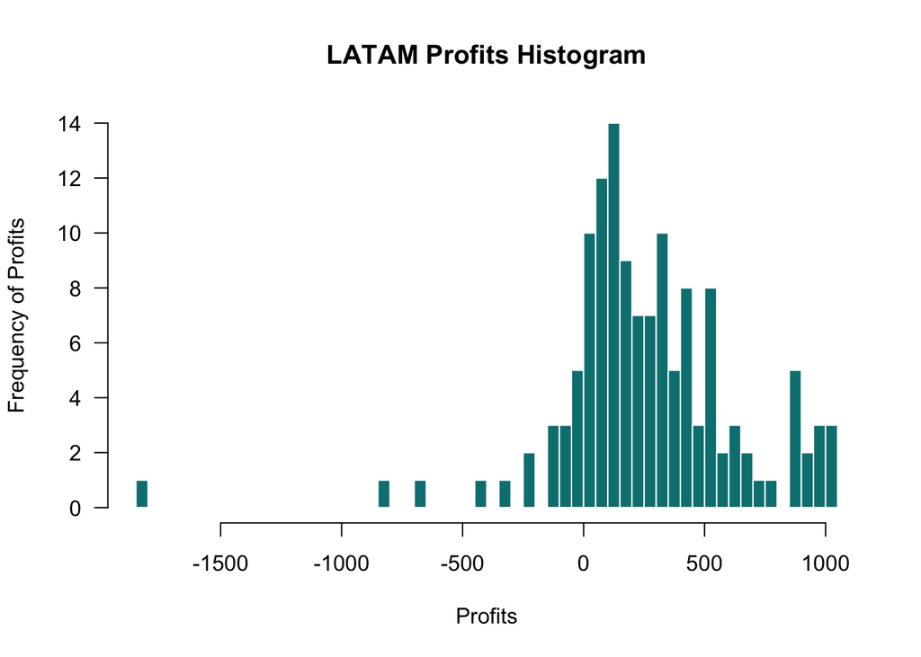

```r
hist(t13LATAM$Profits, breaks = 50, main = "LATAM Profits Histogram", xlab="Profits", ylab = "Frequency of Profits", border="white", col="#008080",las=1)
```

Observation: The spread of the data can be clearly observed combining both the graphs. Profit frequency is more concentrated in the interval sof 0 and 500 as per the histogram, which is the interquartile range as per the boxplot. Frequency spread is more towards the left, which indicates the negative profits.

Task 14

**Using the Latin American data, present a table with the total sales per region**

```r
LATAMRegionalSales <- tapply(t13LATAM$Sales, t13LATAM$Region, sum)
LATAMRegionalSales
```

```
##       Caribbean Central America   South America
##        196775.2        924226.2        457623.3
```

```r
Df5 <- data.frame(Region = c("Caribbean", "Central America", "South America"), Sales = c( 196775.2, 924226.2, 457623.3 ))

Df5%>%
knitr::kable(caption = "<br>**LATAM Regional Sales**", color = "black") %>%
  kableExtra::kable_styling(bootstrap_options = c("striped", "bordered", "hover", "condensed", "responsive", stripe_color = "blue"), full_width = FALSE, position = "left", html_font = "sans")%>%
  gsub("font-size: initial !important;", "font-size: 45pt !important;", .)%>%
  column_spec(2, bold = T, color = "teal", width = "1.5in")%>%
  column_spec(1, bold = T, color = "#515151", width = "1.5in")%>%
  row_spec(0, color = "white", background = "#008080")
```

**LATAM Regional Sales**

| Region | Sales |
| --- | --- |
| Caribbean | 196775.2 |
| Central America | 924226.2 |
| South America | 457623.3 |

Task 15

**Present a box plot displaying the distribution of profits from the 3 regions in the Latin American market**

```r
LATAMRegionalProfits <- tapply(t13LATAM$Profits, t13LATAM$Region, sum)
LATAMRegionalProfits
```

```
##       Caribbean Central America   South America
##         5463.82        21741.95         7723.58
```

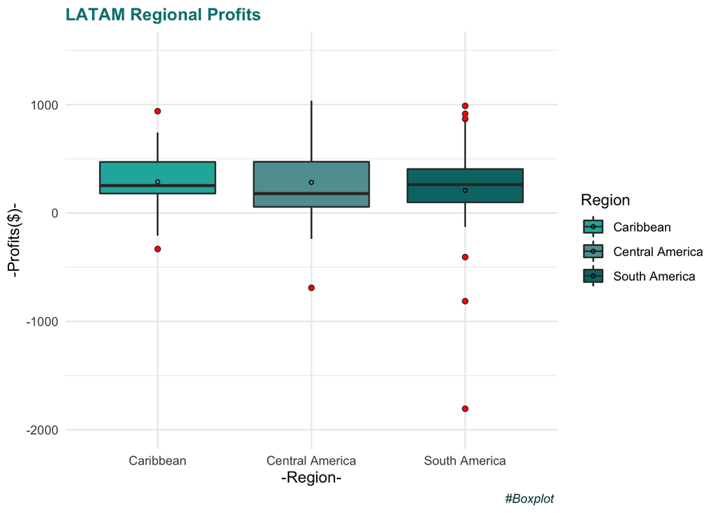

```r
Df6 <- data.frame(Region = c("Caribbean", "Central America", "South America"), Profits = c( 5463.82, 21741.95, 7723.58))


LATAMProfitsRegion <- ggplot(t13LATAM, aes(x = Region, y = Profits, fill=Region))+geom_boxplot()+theme_minimal()
LATAMProfitsRegion+geom_boxplot(outlier.colour="red", outlier.size=1)+stat_summary(fun=mean, geom="point", shape=1, size=1)+scale_fill_manual(values=c("#20b2aa", "#5f9ea0","#007575"))+labs(title = "LATAM Regional Profits", caption = "#Boxplot ", x="-Region-", y="-Profits($)-")+theme(plot.title = element_text(color = "#008080", size = 12, face = "bold"),plot.subtitle = element_text(color = "#282828"),plot.caption = element_text(color = "#004040", face = "italic"))+coord_cartesian(ylim = c(-2000, 1500))
```

Task 16

Observations of Task 13 and 14

Total sales value of LATAM Region is 1578624.7, out of which the major contributor is Central America accounting to about 59%.

CONCLUSIONS

1. what you learnt from the whole work performed.

On a broader scale I have learnt the following and gained the following skills.

1. Usage of different libraries to perform the tasks
2. Different graphs and presentations
3. Creation of data frames
4. Formatting the tables and graphs (dot chart, table, histogram, bar plot)
5. New function Tapply, Filter deducing the data.
6. HTML Codes for formatting.
7. Color Codes and presentation

viii.Analyzing the data using the graphs and plots.

9. Extracting the required data set from the whole
10. How to read the boxplot and histogram combined.
11. Importance of Data presentation and visualisation.

BIBLOGRAPHY

Kassambara, A. (n.d.-b). Plotting with ggplot, Base R. Www.Sthda.Com. Retrieved October 5, 2021, from http://www.sthda.com/english/wiki/ggplot2-essentials

HTML Styles. (n.d.). Www.W3schools.Com. Retrieved October 5, 2021, from https://www.w3schools.com/html/html_styles.asp

Author - Antoine Soetewey 2019-12-30

Becker, R. A., Chambers, J. M. and Wilks, A. R. (1988) The New S Language. Wadsworth & Brooks/Cole.